# Set_24 Unsupervised learning

Alexander Williams

2024-11-29

# Unsupervised Learning

What if we have a set of variables $ x_1,…,X_p$, but no $Y$. How can we find patterns in $X$?

Unsupervised learning is exploratory, and it’s also more subjective. The two main techniques are dimension reduction, and clustering.

**This isn’t prediction, this is primarily for visualization and better understanding.**

Let’s remember how principle component regression, PCR works. We find the direction with the most variance, then continue by finding directions with most variance orthogonal to the rest.
$$z_{i1}=\sum_{j=1}^p\phi_{1j}x_{ip}$$
for $i=1,...,n$.

We can actually find the principle component much easier, as they’re the eigenvectors. We just find those, and we’re good to go.

Once we have them, we plot them against each other in low-dimensional data to try to identify patterns.

# Example

This time we’re looking at a database of arrests in the US. This is unsupervised, so we’re not predicting anything.

```r
states = row.names(USArrests)
states
```

```
##  [1] "Alabama"        "Alaska"         "Arizona"        "Arkansas"
##  [5] "California"     "Colorado"       "Connecticut"    "Delaware"
##  [9] "Florida"        "Georgia"        "Hawaii"         "Idaho"
## [13] "Illinois"       "Indiana"        "Iowa"           "Kansas"
## [17] "Kentucky"       "Louisiana"      "Maine"          "Maryland"
## [21] "Massachusetts"  "Michigan"       "Minnesota"      "Mississippi"
## [25] "Missouri"       "Montana"        "Nebraska"       "Nevada"
## [29] "New Hampshire"  "New Jersey"     "New Mexico"     "New York"
## [33] "North Carolina" "North Dakota"   "Ohio"           "Oklahoma"
## [37] "Oregon"         "Pennsylvania"   "Rhode Island"   "South Carolina"
## [41] "South Dakota"   "Tennessee"      "Texas"          "Utah"
## [45] "Vermont"        "Virginia"       "Washington"     "West Virginia"
## [49] "Wisconsin"      "Wyoming"
```

```r
names(USArrests)
```

```
## [1] "Murder"   "Assault"  "UrbanPop" "Rape"
```

```r
# means of each variable
apply(USArrests , 2, mean)
```

```
##   Murder  Assault UrbanPop     Rape
##    7.788  170.760   65.540   21.232
```

```r
# variance of each variable
apply(USArrests , 2, var)
```

```
##     Murder    Assault   UrbanPop       Rape
##   18.97047 6945.16571  209.51878   87.72916
```

```r
# principle component analysis.
# It's important to scale each component, so that the variance of each one is equal to 1.
pr.out=prcomp(USArrests, scale=TRUE)
names(pr.out)
```

```
## [1] "sdev"     "rotation" "center"   "scale"    "x"
```

```r
pr.out$center
```

```
##   Murder  Assault UrbanPop     Rape
##    7.788  170.760   65.540   21.232
```

```r
pr.out$scale
```

```
##    Murder   Assault  UrbanPop      Rape
##  4.355510 83.337661 14.474763  9.366385
```

```r
pr.out$rotation
```

```
##                 PC1        PC2        PC3         PC4
## Murder   -0.5358995 -0.4181809  0.3412327  0.64922780
## Assault  -0.5831836 -0.1879856  0.2681484 -0.74340748
## UrbanPop -0.2781909  0.8728062  0.3780158  0.13387773
## Rape     -0.5434321  0.1673186 -0.8177779  0.08902432
```

If we multiply the data matrix $X$ by that rotation matrix, we get the principle component scores. the rotation matrix *rotates* the data into the coordinate system of the principle components/eigenvectors

```r
dim(pr.out$x)
```

```
## [1] 50  4
```

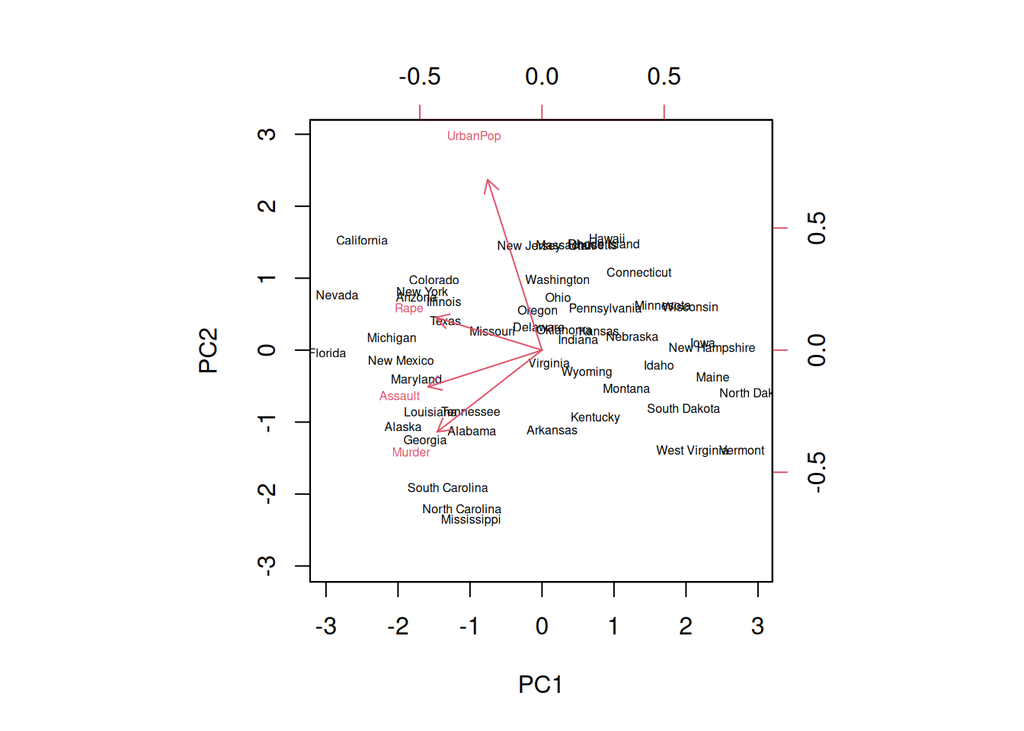

```r
biplot(pr.out, cex =0.5,scale=0)
```

this is mirrored compared to the example above, we can fix that by swapping the signs on the rotation matrix

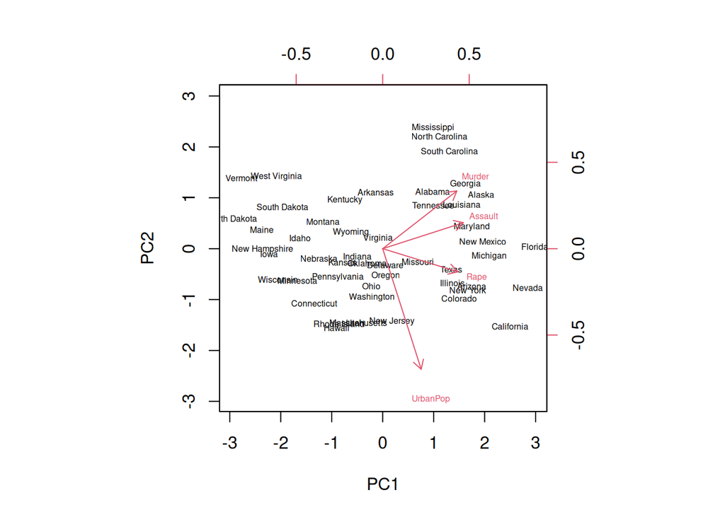

```r
pr.out$rotation=-pr.out$rotation
pr.out$x=-pr.out$x
biplot(pr.out,cex = 0.5, scale=0)
```

This plot is a bit weird to read, but the key takeaway is that *points that are close to each other have similar attributes*. This won’t tell you exactly what they are, but it can help us find patterns.

```r
pr.out$sdev
```

```
## [1] 1.5748783 0.9948694 0.5971291 0.4164494
```

```r
pr.var=pr.out$sdev^2
pr.var
```

```
## [1] 2.4802416 0.9897652 0.3565632 0.1734301
```

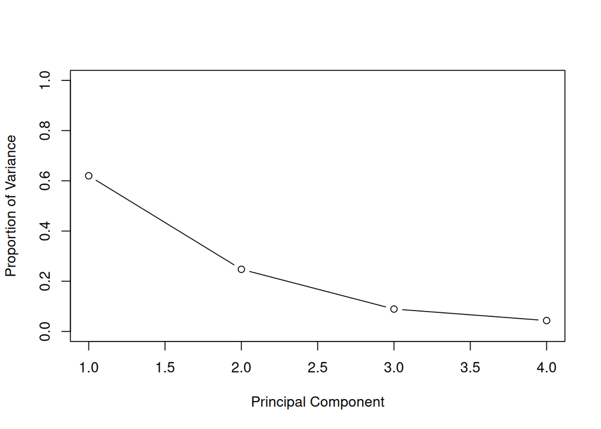

```r
# Get the proportion of variance, to see how variance changes as we increase the number of principle components
pve=pr.var/sum(pr.var)
plot(pve,
     xlab = 'Principal Component',
     ylab = 'Proportion of Variance',
     ylim = c(0,1),
     type = 'b')
```

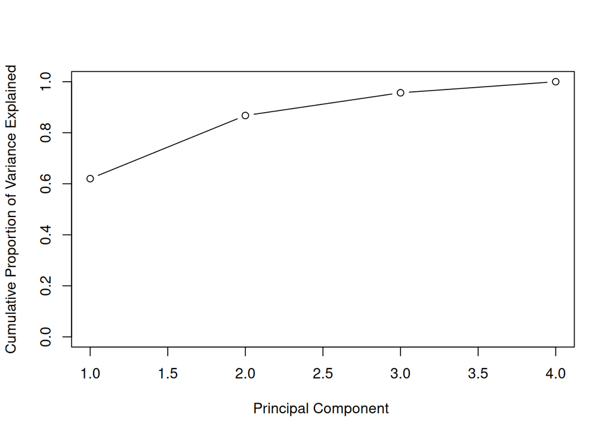

```r
# cumsum == "cumulative sum"
plot(cumsum(pve),
     xlab="Principal Component ",
     ylab=" Cumulative Proportion of Variance Explained ",
     ylim=c(0,1), type='b')
```

# Clustering: K-means

Also covered in SENG474 notes, with more details but no implementation.

The goal of clustering is to see which datapoints are similar to each other. They may form groups of similar points. Clustering is a way to identify these distinct groups

Given $n$ points with $p$ dimensions, represented in a $n\times{}p$ matrix.

K-means clustering creates $K$ groups in the data, assigning every point to a cluster. The goal is to reduce variability in each cluster.

Let $W(C_k)$ denote the degree that observations in a cluster $C_k$ differ from one another. This means the goal of K-mean is to minimize the sum of all $W(C_k)$.

There’s a number of ways to define the function $W()$. The simplest is to compute the average distance. Get the distance from every point in a cluster to every other point, square their distance, and take the sum of them all.

here’s the basic idea of the algorithm:

1. place $K$ points in the data space. These will be the centroids of each cluster
2. Place every datapoint in a cluster depending on their closest centroid.
3. Move each centroid to the center of all points in its cluster
4. Repeat until no points change clusters. At this point, the algorithm is complete.

**Different method**

1. Assign every point to one of $K$ groups entirely at random
2. Compute the centroid of each group
3. move each datapoint into the cluster of the closest centroid
4. Repeat until no points change clusters.

Note that while this algorithm will always converge, it may only converge to a local optimum, not the global optimum.